# Module 5 Homework

In this assignment, we're going to tackle the most important aspect of time-series modeling: how to backtest our model!

Learning objectives:

- Why do we need to backtest a time-series forecasting model
- How to do pseudo-out-of-sample testing
- How to do rolling pseudo-out-of-sample testing

We understand the importance of testing our models in general. If we didn't test our models, we wouldn't know if they're overfitting or underfitting, for example. A model that won't behave well out-of-sample (on observations it hasn't seen yet) is pretty much as useless to us as no model at all.

Testing a time-series model is more involved than testing most other machine learning models, and so we have dedicated an entire module to it.

# 1) Imports and setup

For continuity, we're going to use the same dataset as our prior time-series module. Let's read in the data, change the index to a datetime format, and plot the data at a monthly frequency.

```python
# run this cell
import pandas as pd
import matplotlib.pyplot as plt
from statsmodels.tsa.arima.model import ARIMA
from sklearn.metrics import mean_squared_error
from math import sqrt
```

Read in the data file, `daily-minimum-temperatures-in-me.csv`. In the `read_csv` method, remember to set the index column to the first column in the csv. Then, in a second step, recast this index to be of the data type datetime.

```python
# TODO read in the csv and recast the index to datetime format

daily_min_temp_df = pd.read_csv('C:/Users/iamontes/Python Projects/Finance ML Certificate/Module_4/daily-minimum-temperatures-in-me.csv', infer_datetime_format=True, header=0, index_col=0, names=['day', 'temp'], on_bad_lines='skip')

daily_min_temp_df.index = pd.to_datetime(daily_min_temp_df.index)
```

```python
# Convert the 'Daily Min Temp' column to numeric, coercing errors to NaN
daily_min_temp_df['temp'] = pd.to_numeric(daily_min_temp_df['temp'], errors='coerce')

# Optionally drop rows with NaN values (if desired)
daily_min_temp_df.dropna(inplace=True)

daily_min_temp_df.info()
```

```
<class 'pandas.core.frame.DataFrame'>
DatetimeIndex: 3647 entries, 1981-01-01 to 1990-12-31
Data columns (total 1 columns):
 #   Column  Non-Null Count  Dtype
---  ------  --------------  -----
 0   temp    3647 non-null   float64
dtypes: float64(1)
memory usage: 57.0 KB
```

Create a new dataframe with the temp data at a monthly frequency. Then plot the monthly data using maptplotlib.

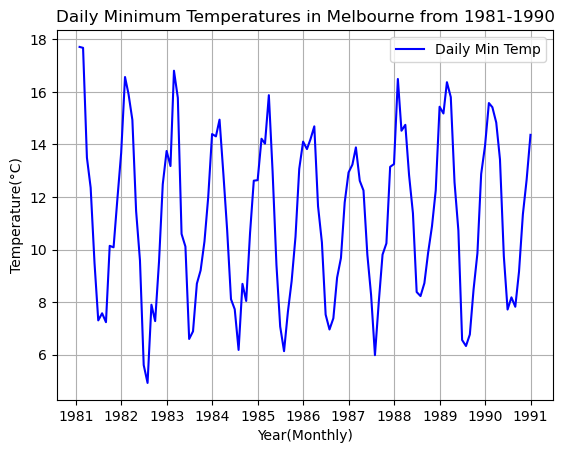

```python
# TODO create a new dataframe with the data at a monthly frequency
monthly_min_temp_df = daily_min_temp_df.resample('M').mean()

# TODO plot the monthly data
plt.plot(monthly_min_temp_df.index, monthly_min_temp_df['temp'], label='Daily Min Temp', color='blue')

plt.title('Daily Minimum Temperatures in Melbourne from 1981-1990')
plt.xlabel('Year(Monthly)')
plt.ylabel('Temperature(°C)')
plt.legend()
plt.grid()
plt.show()
```

## 2) Create AR model

To have a model to test, we'll first need to create a model. We'll stick with an AR model for now. Using the `ARIMA` method from `statsmodels` to set up an AR model. How do you know which lag order to use? Well, we're using the same data as our prior time-series homework, so you can take a peak there for a hint. Remember, you should use a PACF chart to find the AR lag! Go ahead and do that here (you can just use the same lag as in the prior homework, if you'd prefer to skip plotting a PACF chart).

```python
# TODO use ARIMA to fit an AR model; which lag order should you use?
AR = ARIMA(monthly_min_temp_df.temp,order=(9,1,0)).fit() # order = (p,d,q) = (AR, difference, MA)

AR.summary()
```

SARIMAX Results

| Dep. Variable: | temp | No. Observations: | 120 |
| --- | --- | --- | --- |
| Model: | ARIMA(9, 1, 0) | Log Likelihood | -186.852 |
| Date: | Sun, 27 Oct 2024 | AIC | 393.704 |
| Time: | 10:52:32 | BIC | 421.495 |
| Sample: | 01-31-1981 | HQIC | 404.989 |
|  | - 12-31-1990 |  |  |
| Covariance Type: | opg |  |  |

|  | coef | std err | z | P>\|z\| | [0.025 | 0.975] |
| --- | --- | --- | --- | --- | --- | --- |
| ar.L1 | -0.3474 | 0.100 | -3.476 | 0.001 | -0.543 | -0.152 |
| ar.L2 | -0.0683 | 0.080 | -0.858 | 0.391 | -0.224 | 0.088 |
| ar.L3 | -0.1811 | 0.093 | -1.942 | 0.052 | -0.364 | 0.002 |
| ar.L4 | -0.3500 | 0.084 | -4.145 | 0.000 | -0.515 | -0.184 |
| ar.L5 | -0.3725 | 0.068 | -5.484 | 0.000 | -0.506 | -0.239 |
| ar.L6 | -0.2990 | 0.077 | -3.892 | 0.000 | -0.450 | -0.148 |
| ar.L7 | -0.2764 | 0.085 | -3.246 | 0.001 | -0.443 | -0.110 |
| ar.L8 | -0.5140 | 0.078 | -6.591 | 0.000 | -0.667 | -0.361 |
| ar.L9 | -0.2864 | 0.105 | -2.726 | 0.006 | -0.492 | -0.080 |
| sigma2 | 1.2879 | 0.179 | 7.184 | 0.000 | 0.937 | 1.639 |

| Ljung-Box (L1) (Q): | 1.76 | Jarque-Bera (JB): | 1.17 |
| --- | --- | --- | --- |
| Prob(Q): | 0.18 | Prob(JB): | 0.56 |
| Heteroskedasticity (H): | 0.57 | Skew: | 0.22 |
| Prob(H) (two-sided): | 0.08 | Kurtosis: | 3.21 |

Warnings:  
[1] Covariance matrix calculated using the outer product of gradients (complex-step).

```python
import statsmodels.tsa.api as smt
import seaborn as sns

def acf_pacf_plots(data, lags=None):
    # create the structure for the plots
    layout = (1, 3)
    raw  = plt.subplot2grid(layout, (0, 0))
    acf  = plt.subplot2grid(layout, (0, 1))
    pacf = plt.subplot2grid(layout, (0, 2))

    # create the actual plots
    data.plot(ax=raw, figsize=(12, 6))
    smt.graphics.plot_acf(data, lags=lags, ax=acf)
    smt.graphics.plot_pacf(data, lags=lags, ax=pacf)
    sns.despine()
    plt.tight_layout()
```

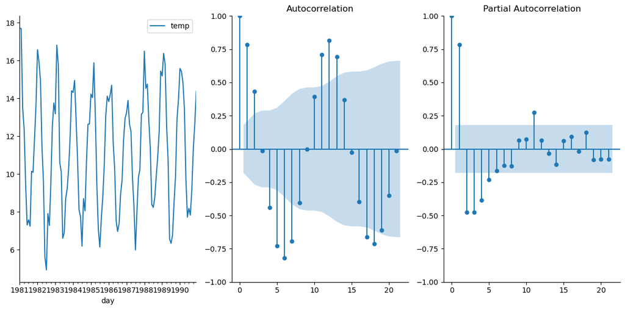

```python
acf_pacf_plots(monthly_min_temp_df)
```

## 3) In-sample prediction

When we use our model to predict for time stamps that we already have data for, we call that **in-sample prediction.** When we'd like to know what our model thinks will happen in the future, for time stamps where we don't have data, we call that **out-of-sample forecasting**.

Let's practice our in-sample prediction and plotting before we get to out-of-sample testing.

Now we'll want to get the in-sample predictions from the AR model we just built. Use `.predict` to do so.

```python
# TODO create then in-sample predictions using .predict
# start at time stamp 30, for example
# try different starting points and plot each one!

in_sample = AR.predict(start=30,end=len(monthly_min_temp_df), dynamic=True)
```

Now that we have our `in_sample` prediction data, plot the predictions and the monthly actual data on the same chart.

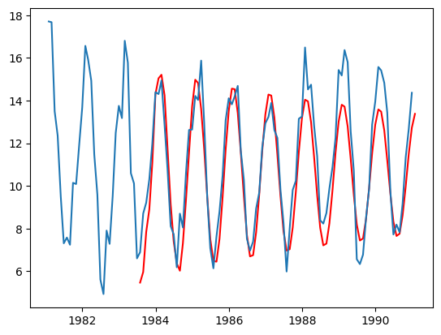

```python
# TODO plot the actual and in-sample prediction on the same plot
plt.plot(in_sample, color='red')
plt.plot(monthly_min_temp_df);
```

## 4) Out-of-sample prediction

Let's do one **true out-of-sample prediction.** To do so, we'll again use `.predict` from `statsmodels`, but we'll want to start at the end of our actual data and go one year into the future.

To do so, set start to the length of our actual monthly data minus one (the minus one is so that our actual and prediction connect). Then set the end to be the length of our actual monthly data plus 12; this will predict out 12 time stamps or 12 months.

```python
# TODO create out_of_sample data using .predict

out_of_sample = AR.predict(start=len(monthly_min_temp_df)-1, end=len(monthly_min_temp_df)+12, dynamic=True)
```

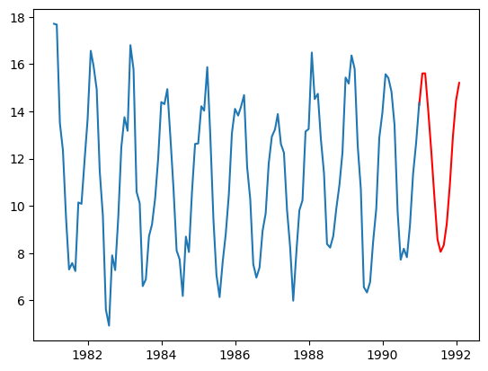

```python
# TODO plot the actual and out-of-sample on the same plot
# use a different color for out of sample so you can tell them apart (for example, plot(color='red'))
plt.plot(out_of_sample, color='red')
plt.plot(monthly_min_temp_df);
```

## 5) Psuedo out-of-sample prediction, or train/test split for time-series

Above we did a real out-of-sample prediction by looking at 12 months into the future. But, in order to **backtest** our model, we need to do **pseudo (or fake) out-of-sample prediction**. This is how it will work:

- Pretend as if we have less data than we actually do
- Build a model on the smaller dataset that excludes the data we're pretending not to have
- Compare the out-of-sample forecast built on the smaller dataset with the actual data for those timestamps

We can think of this as a **train/test split for time series**.

Create a pseudo out-of-sample dataset. Call the dataset we'll build our model on `train` and the part we'll hold out as the psuedo out-of-sample `test`.

To start, hold out the last 12 time steps (aka 12 months) of data.

```python
# TODO create train and test series
train = monthly_min_temp_df[:12]
test = monthly_min_temp_df[36:]
print(len(train))
print(len(test))
```

```
12
84
```

Now we'll **fit on train** and **test on test**!

```python
# TODO use ARIMA().fit() to fit on the train dataset only
# remember, use MONTHLY data and use I = 1 to use a first-difference, aka stationary series
AR_train = ARIMA(train.temp,order=(9,1,0)).fit()

AR.summary()
```

SARIMAX Results

[output not shown]

[output not shown]

[output not shown]

Warnings:  
[1] Covariance matrix calculated using the outer product of gradients (complex-step).

```python
# TODO use your fitted model from above, plus .predict(), to predict on the training data
# start = len(train)
# end = len(train) + ?

test_pred = AR_train.predict(start=len(train), end=len(train)+83, dynamic=True)
len(test_pred)
```

```
84
```

In the prior homework for our introductory time-series module, we plotted only the out-of-sample and the prediction. In this case, we're going to change that a little and plot the full time-series against the pseudo out-of-sample forecast. This will help us see how our rolling out-of-sample testing works!

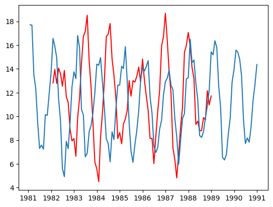

```python
# TODO plot test and the full dataset on the same plot
plt.plot(test_pred, color='red');
plt.plot(monthly_min_temp_df);
```

Now calculate the RMSE on the data we held out. We imported `sqrt` from the math module and `mean_squared_error` from `sklearn` at the very top of this notebook, so feel free to use them now.

```python
# TODO calculate RMSE using the test dataset (what we held out) and the test_pred

rmse = sqrt(mean_squared_error(test, test_pred))
```

```python
# TODO run this cell to check your RMSE

print(f'RMSE = {rmse:.2f} degrees Celsius')
```

```
RMSE = 4.61 degrees Celsius
```

## 6) Rolling out-of-sample testing

Doing a single out-of-sample train/test split is all well and good, but we need to do more. That's where rolling out-of-sample testing comes in. What we'll want to do now is the systematically hold out a large amount of data, run a model, then hold out slightly less data and repeat. Let's do it!

## 6a) Build model on first 24 months of data

Re-do the train/test split from above, but now hold out everything *except* the first 24 months of data.

```python
# TODO create train and test series
# hold out everything except the first 12 months

train = monthly_min_temp_df[:24]
test = monthly_min_temp_df[24:]
print(len(train))
print(len(test))
```

```
24
96
```

```python
# TODO use ARIMA().fit() to fit on the train dataset only
# remember, use MONTHLY data and use I = 1 to use a first-difference, aka stationary series
AR_train = ARIMA(train.temp,order=(9,1,0)).fit()

AR.summary()
```

SARIMAX Results

[output not shown]

[output not shown]

[output not shown]

Warnings:  
[1] Covariance matrix calculated using the outer product of gradients (complex-step).

```python
# TODO use your fitted model from above, plus .predict(), to predict on the training data
test_pred = AR_train.predict(start=len(train), end=len(monthly_min_temp_df)-1, dynamic=True)
```

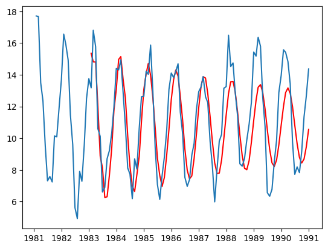

```python
# TODO plot test and the full dataset on the same plot
plt.plot(test_pred, color='red');
plt.plot(monthly_min_temp_df);
```

```python
# TODO calculate the RMSe on the model and print it out

rmse = sqrt(mean_squared_error(test, test_pred))
print(f'RMSE = {rmse:.2f} degrees Celsius')
```

```
RMSE = 1.82 degrees Celsius
```

**Check for understanding**: What is the RMSE on this model that uses only the first 24 months of data? Is it better or worse than our original model above? Is this what you'd expect?

### # TODO write a few sentences to answer the above question

.The RMSE is much better than the one with 12 months .The example with 12 months reached 4 degrees in rmse, while the with train data of 24 reached 1.8 degress in rmse .This is what would be expected since we are using more data for training the model.

## 6b) Build model on first 36 months of data

Let's keep rolling! Now we'll build our model on the first three years of data. Repeat the above steps, including train/test splitting, fitting the model, predicting, plotting and calculating RMSE.

```python
# TODO run the next "roll" of our rolling pseudo out-of-sample testing by adding one more year to the train data

train = monthly_min_temp_df[:36]
test = monthly_min_temp_df[36:]
print(len(train))
print(len(test))
```

```
36
84
```

```python
AR_train = ARIMA(train.temp,order=(9,1,0)).fit()

AR_train.summary()
```

SARIMAX Results

[output not shown]

[output not shown]

[output not shown]

Warnings:  
[1] Covariance matrix calculated using the outer product of gradients (complex-step).

```python
# then predict, plot and calculate RMSE
test_pred = AR_train.predict(start=len(train), end=len(monthly_min_temp_df)-1, dynamic=True)
```

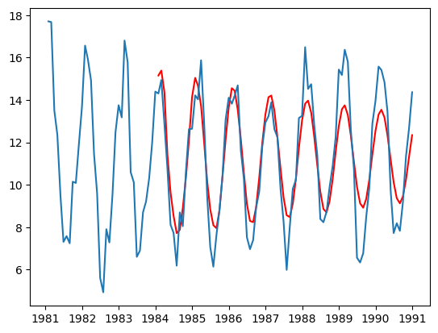

```python
plt.plot(test_pred, color='red');
plt.plot(monthly_min_temp_df);
```

```python
# TODO calculate the RMSe on the model and print it out

rmse = sqrt(mean_squared_error(test, test_pred))
print(f'RMSE = {rmse:.2f} degrees Celsius')
```

```
RMSE = 1.31 degrees Celsius
```

## 6c) Keep rolling! Build on first 48 months of data

Let's try this one more time, this time building on the first 48 months of data.

```python
# TODO run the next "roll" of our rolling pseudo out-of-sample testing by adding one more year to the train data

train = monthly_min_temp_df[:48]
test = monthly_min_temp_df[48:]
print(len(train))
print(len(test))
```

```
48
72
```

```python
AR_train = ARIMA(train.temp,order=(9,1,0)).fit()

AR_train.summary()
```

SARIMAX Results

[output not shown]

[output not shown]

[output not shown]

Warnings:  
[1] Covariance matrix calculated using the outer product of gradients (complex-step).

```python
# then predict, plot and calculate RMSE
test_pred = AR_train.predict(start=len(train), end=len(monthly_min_temp_df)-1, dynamic=True)
```

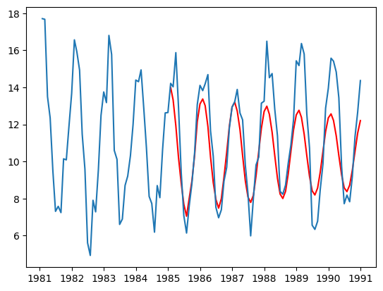

```python
plt.plot(test_pred, color='red');
plt.plot(monthly_min_temp_df);
```

```python
# TODO calculate the RMSe on the model and print it out

rmse = sqrt(mean_squared_error(test, test_pred))
print(f'RMSE = {rmse:.2f} degrees Celsius')
```

```
RMSE = 1.73 degrees Celsius
```

**Check for understanding**: Write out a few sentences about what you saw! Did the RMSE fall again when we used the first 48 months of data? Hint: No, it didn't! Is this what you would expect? Why did the RMSE go up, even though we used more data in our model? Check the graph of the actual data vs. the prediction for help in answering this!

### # TODO write a few sentences to answer the above question

.It surprisingly didn't go down, RMSE rose to 1.73 degrees from 1.3. .This is an example of overfitting, we fed more data to the model, but this just made it overfit. .The graph was very useful at telling me that the forecast was less accurate than the previous graph since it shows the prediction with less volatility than the actual values. -Though if we continue using more data we risk overfitting.

## 7) Write a loop to automate out-of-sample testing

Let's put it all together now! Write a for-loop to automate your pseudo out-of-sample testing. Start with the first 24 months of data in your training set, and in each step add another 12 months.

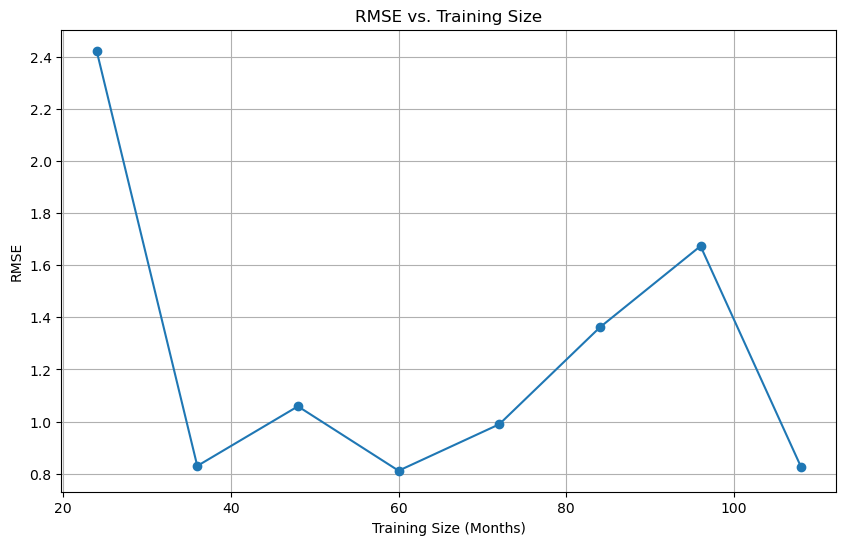

```python
# TODO build a loop to automate pseudo out-of-sample testing

import pandas as pd
import numpy as np
import matplotlib.pyplot as plt
from statsmodels.tsa.ar_model import AutoReg
from sklearn.metrics import mean_squared_error

# store the RMSE from each run in a list, then plot that list as a line graph to see how it changes as you add more data

# Create an empty list to store RMSE values
rmse_list = []

# Define the initial training size and increment size
initial_train_size = 24  # months
increment_size = 12      # months

# Loop through the dataset
for start in range(initial_train_size, len(monthly_min_temp_df), increment_size):
    # Define training and testing sets
    train = monthly_min_temp_df['temp'][:start]
    test = monthly_min_temp_df['temp'][start:start + increment_size]

    # Fit the AR model
    model = AutoReg(train, lags=9)  # Adjust lag as needed
    model_fit = model.fit()

    # Make predictions
    predictions = model_fit.predict(start=len(train), end=len(train) + len(test) - 1)

    # Calculate RMSE
    rmse = np.sqrt(mean_squared_error(test, predictions))
    rmse_list.append(rmse)

# Plotting RMSE values
plt.figure(figsize=(10, 6))
plt.plot(range(initial_train_size, len(monthly_min_temp_df), increment_size), rmse_list, marker='o')
plt.title('RMSE vs. Training Size')
plt.xlabel('Training Size (Months)')
plt.ylabel('RMSE')
plt.grid()
plt.show()
```

**Check for understanding**: Why do we have to start with 24 months of data? Why didn't we start with 12 months, or even fewer? Remember how an AR model works, particularly what the AR lag means! Compare this to the value we used for our AR lag in this particular model. Could we build a model with fewer datapoints than our lag? Try and see what `statsmodels` tells you!

## 8) How to use rolling pseudo out-of-sample testing in practice

Now that we've had some practice with rolling pseudo out-of-sample testing, let's take a moment to reflect on what it all means. Did the RMSE always go down as we added more data? Nope! Sometimes it went up! That's because our time-series, although it's stationary, doesn't always have the same exact statistical properties over every cut of the data. That is, each training set didn't look exactly the same, so some may have had spikes or dips that affected our forecast.

Also, remember that time-series forecasts are valid only for a few time stamps out from the end of our data! They will degrade as we go out too far.

In fact, take a moment to answer this question: **what happens to a time-series forecast as it's extended far into the future?** How can we answer this question? We can look at our early out-of-sample performance, for example when we built our model on only the first 24 months of data. Look at the model forecast vs. the actual over time. Do you notice something about the forecast? You should notice that, the longer we go out into the future, the more that the forecast becomes just the mean of the training set.

**Do an experiment**: run a forecast an absurd amount of time into the future, say 36 or 48 months. What do you notice?

```python
# TODO run experiment where you forecast an absurd amount of time into the future, such as 3, 4 or even 10 years

train = monthly_min_temp_df[:24]
test = monthly_min_temp_df[24:]
print(len(train))
print(len(test))
```

```
24
96
```

```python
# TODO use ARIMA().fit() to fit on the train dataset only
# remember, use MONTHLY data and use I = 1 to use a first-difference, aka stationary series
AR_train = ARIMA(train.temp,order=(9,1,0)).fit()

AR_train.summary()
```

SARIMAX Results

| Dep. Variable: | temp | No. Observations: | 24 |
| --- | --- | --- | --- |
| Model: | ARIMA(9, 1, 0) | Log Likelihood | -40.753 |
| Date: | Sun, 27 Oct 2024 | AIC | 101.506 |
| Time: | 10:55:11 | BIC | 112.861 |
| Sample: | 01-31-1981 | HQIC | 104.361 |
|  | - 12-31-1982 |  |  |
| Covariance Type: | opg |  |  |

|  | coef | std err | z | P>\|z\| | [0.025 | 0.975] |
| --- | --- | --- | --- | --- | --- | --- |
| ar.L1 | -0.2275 | 0.314 | -0.724 | 0.469 | -0.843 | 0.388 |
| ar.L2 | -0.0114 | 0.328 | -0.035 | 0.972 | -0.654 | 0.631 |
| ar.L3 | -0.1147 | 0.373 | -0.307 | 0.759 | -0.846 | 0.617 |
| ar.L4 | -0.3697 | 0.344 | -1.074 | 0.283 | -1.044 | 0.305 |
| ar.L5 | -0.3556 | 0.344 | -1.035 | 0.301 | -1.029 | 0.318 |
| ar.L6 | -0.3816 | 0.480 | -0.795 | 0.427 | -1.323 | 0.560 |
| ar.L7 | -0.1497 | 0.360 | -0.416 | 0.677 | -0.855 | 0.555 |
| ar.L8 | -0.2233 | 0.367 | -0.608 | 0.543 | -0.944 | 0.497 |
| ar.L9 | -0.4996 | 0.371 | -1.346 | 0.178 | -1.227 | 0.228 |
| sigma2 | 1.5332 | 0.977 | 1.569 | 0.117 | -0.382 | 3.448 |

| Ljung-Box (L1) (Q): | 2.55 | Jarque-Bera (JB): | 7.76 |
| --- | --- | --- | --- |
| Prob(Q): | 0.11 | Prob(JB): | 0.02 |
| Heteroskedasticity (H): | 1.30 | Skew: | 1.15 |
| Prob(H) (two-sided): | 0.72 | Kurtosis: | 4.69 |

Warnings:  
[1] Covariance matrix calculated using the outer product of gradients (complex-step).

```python
# then predict, plot and calculate RMSE
test_pred = AR_train.predict(start=len(train), end=len(monthly_min_temp_df)+24, dynamic=True)
```

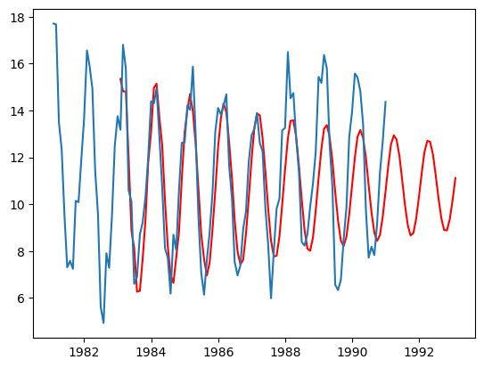

```python
plt.plot(test_pred, color='red');
plt.plot(monthly_min_temp_df);
```

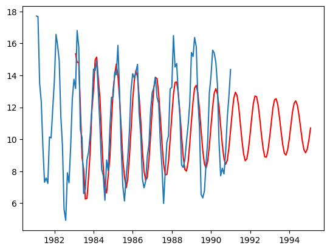

```python
# then predict, plot and calculate RMSE
test_pred = AR_train.predict(start=len(train), end=len(monthly_min_temp_df)+48, dynamic=True)

plt.plot(test_pred, color='red');
plt.plot(monthly_min_temp_df);
```

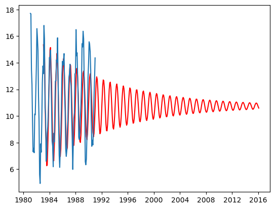

```python
# then predict, plot and calculate RMSE
test_pred = AR_train.predict(start=len(train), end=len(monthly_min_temp_df)+300, dynamic=True)

plt.plot(test_pred, color='red');
plt.plot(monthly_min_temp_df);
```

**Do an experiment**: run a forecast an absurd amount of time into the future, say 36 or 48 months. What do you notice?

- The data just defaults to the mean, the volatility of the forecast decreases and we are not aloud to capture the trend or volatility.
- This example makes it clear that ARIMA should only be used for near future forecasts .

**In practice, we use the stability of pseudo out-of-sample testing to judge our model.** That is, we saw above that our RMSE didn't always go down, even as we added more data. When we use this paradigm of testing, this is what we look for to judge if our model is indeed good:

- A good model should (in general) have decreasing RMSE as we add more data
- It's ok if the RMSE doesn't *always* decrease as we add data, but in general the trend should be down
- The model should become more stable as we add more data to our training set: that is, it should fit to any spikes better as we add training data

This is **not an exact science!** Rather, we take the whole of our rolling psuedo out-of-sample testing into consideration when we're trying to judge whether our model is behaving well.

## 9) A word of warning about time-series forecasting in finance

Out-of-sample testing in time-series modeling is a [complex issue](https://www.researchgate.net/publication/247087596_Out-of_sample_tests_of_forecasting_accuracy_an_analysis_and_review). We saw one very popular approach, but there are several ways it can be amended. However, what we need to know when we use time-series modelig in the real world is that no amount of testing will lead to perfect models.

Especially in finance applications of time-series modeling, the past is not a perfect guide to the future. If it were possible, for example, to predict future prices well enough to beat the market, then everyone would do it. But of course that's not possible. So I'd like to leave you with this warning: even **a successful backtest does not prove anything about cause/effect**. A backtest is not an experiment of what might happen in the future, it is simple a single hypothetical of what happened in the past. Do not overly rely on a backtest!

So then why did we just spend all this time doing rolling backtests? Well, a backtest is not completely useless. A backtest, especially as we did here with a rolling sample, does give us some information about our model. It could tell us, for example, if our model is completely ill-fit.

A common use of backtests in finance is for [**scenario analysis**](https://www.investopedia.com/terms/s/scenario_analysis.asp). Scenario analysis is beyond the scope of our course as it involves multiplte time-series (instead of a single series used in ARIMA), but it's helpful to understand in theory. A scenario analysis involves seeing how our time series would react if certain input variables are changed. For example, if we're modeling the amount of deposits in checking accounts that a bank will have over time, we can change the unemployment rate in each scenario and check how the balances do. Scenario analysis in this way is often used by central banks to check the health of the banks they regulate.